# Métodos Supervisados

2022-08-26

# Introducción

### En este documento se abarcarán los siguientes temas:

- El Método de los K Vecinos Más Cercanos
- Gráfico de Distribución de la Variable a Predecir.
- Gráficos de Poder Predictivo.

# Paquetes, Módulos y Funciones

Se hará uso de los siguientes Paquetes, Módulos y Funciones

## Módulos

```python
import os
import pandas as pd
import numpy as np
import matplotlib.pyplot as plt
from matplotlib import colors as mcolors
from sklearn.preprocessing import StandardScaler
from sklearn.model_selection import train_test_split
from sklearn.neighbors import KNeighborsClassifier
from sklearn.metrics import confusion_matrix
import seaborn as sns
```

## Índices Generales

**Función para calcular los índices de calidad de la predicción**

```python
def indices_general(MC, nombres = None):
    precision_global = np.sum(MC.diagonal()) / np.sum(MC)
    error_global     = 1 - precision_global
    precision_categoria  = pd.DataFrame(MC.diagonal()/np.sum(MC,axis = 1)).T
    if nombres!=None:
        precision_categoria.columns = nombres
    return {"Matriz de Confusión":MC,
            "Precisión Global":   precision_global,
            "Error Global":       error_global,
            "Precisión por categoría":precision_categoria}
```

## Distribución

**Función para graficar la distribución de la variable a predecir**

```python
import matplotlib.ticker as mticker

def distribucion_variable_predecir(data:pd.DataFrame,variable_predict:str, ax = None):
    if ax == None:
        fig, ax = plt.subplots(1,1, figsize = (15,10), dpi = 200)
    colors = list(dict(**mcolors.CSS4_COLORS))
    df = pd.crosstab(index = data[variable_predict],columns = "valor") / data[variable_predict].count()
    countv = 0
    titulo = "Distribución de la variable %s" % variable_predict

    for i in range(df.shape[0]):
        ax.barh(1, df.iloc[i], left = countv, align = 'center', color = colors[11 + i], label = df.iloc[i].name)
        countv = countv + df.iloc[i]

    ax.set_xlim(0,1)
    ax.set_yticklabels("")
    ax.set_ylabel(variable_predict)
    ax.set_title(titulo)
    ticks_loc = ax.get_xticks().tolist()
    ax.xaxis.set_major_locator(mticker.FixedLocator(ticks_loc))
    ax.set_xticklabels(['{:.0%}'.format(x) for x in ticks_loc])

    countv = 0
    for v in df.iloc[:,0]:
        ax.text(np.mean([countv, countv + v]) - 0.03, 1 , '{:.1%}'.format(v), color = 'black', fontweight = 'bold')
        countv = countv + v
    ax.legend(loc = 'upper center', bbox_to_anchor = (1.08, 1), shadow = True, ncol = 1)
```

## Poder Predictivo

**Función para ver la distribución de una variable categórica respecto a la predecir**

```python
def poder_predictivo_categorica(data: pd.DataFrame, var: str, variable_predict: str, ax=None):
    if ax == None:
        fig, ax = plt.subplots(1, 1, figsize = (15, 10), dpi = 200)
    df = pd.crosstab(index = data[var], columns = data[variable_predict])
    df = df.div(df.sum(axis = 1), axis = 0)
    titulo = "Distribución de la variable %s según la variable %s" % (var, variable_predict)
    df.plot(kind = 'barh', stacked = True,   legend = True, ax = ax,
            xlim = (0, 1), title   = titulo, width = 0.8)

    ticks_loc = ax.get_xticks().tolist()
    ax.xaxis.set_major_locator(mticker.FixedLocator(ticks_loc))
    ax.set_xticklabels(['{:.0%}'.format(x) for x in ticks_loc])
    ax.legend(loc = 'upper center', bbox_to_anchor = (1.08, 1),
              shadow = True, ncol = 1)

    for bars in ax.containers:
        plt.setp(bars, width = .9)
    for i in range(df.shape[0]):
        countv = 0
        for v in df.iloc[i]:
            ax.text(np.mean([countv, countv+v]) - 0.03, i,
                    '{:.1%}'.format(v), color = 'black', fontweight = 'bold')
            countv = countv + v
```

**Función para ver la distribución de una variable numérica respecto a la predecir**

```python
def poder_predictivo_numerica(data:pd.DataFrame, var:str, variable_predict:str):
    sns.FacetGrid(data, hue = variable_predict, height = 8, aspect = 1.8).map(sns.kdeplot, var, shade = True).add_legend()
```

# Ejemplo Datos de Iris

**Lectura de datos**

```python
datos = pd.read_csv('../datos/iris.csv',delimiter = ';',decimal = ".")
print("Iris.shape: ", datos.shape, "\n")
```

```
Iris.shape:  (150, 5)
```

```python
print(datos.info(), "\n")
```

```
<class 'pandas.core.frame.DataFrame'>
RangeIndex: 150 entries, 0 to 149
Data columns (total 5 columns):
 #   Column   Non-Null Count  Dtype
---  ------   --------------  -----
 0   s.largo  150 non-null    float64
 1   s.ancho  150 non-null    float64
 2   p.largo  150 non-null    float64
 3   p.ancho  150 non-null    float64
 4   tipo     150 non-null    object
dtypes: float64(4), object(1)
memory usage: 6.0+ KB
None
```

```python
datos.head()
```

```
   s.largo  s.ancho  p.largo  p.ancho    tipo
0      5.1      3.5      1.4      0.2  setosa
1      4.9      3.0      1.4      0.2  setosa
2      4.7      3.2      1.3      0.2  setosa
3      4.6      3.1      1.5      0.2  setosa
4      5.0      3.6      1.4      0.2  setosa
```

### **Distribución de la variable a predecir**

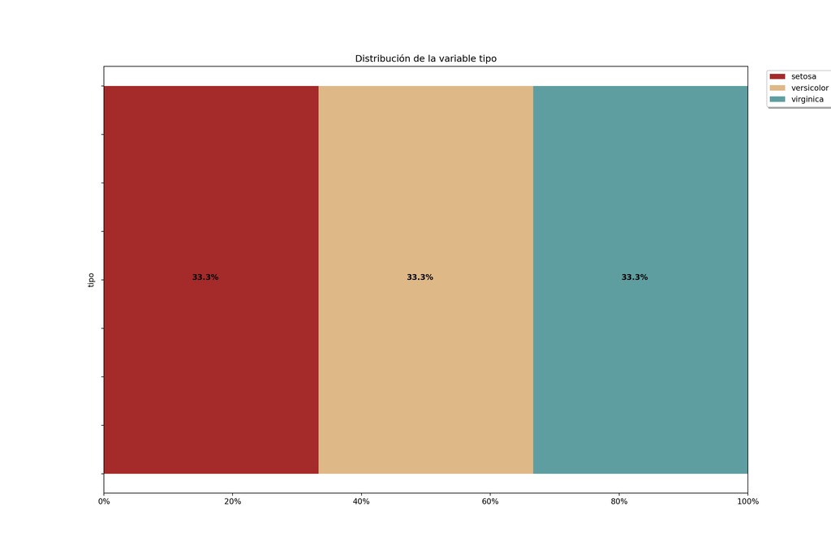

```python
distribucion_variable_predecir(datos,"tipo")
plt.show()
```

**Guardamos las variables predictoras en X**

```python
X = datos.iloc[:,:4]
X = pd.DataFrame(StandardScaler().fit_transform(X), columns= X.columns)
X.head()
```

```
    s.largo   s.ancho   p.largo   p.ancho
0 -0.900681  1.032057 -1.341272 -1.312977
1 -1.143017 -0.124958 -1.341272 -1.312977
2 -1.385353  0.337848 -1.398138 -1.312977
3 -1.506521  0.106445 -1.284407 -1.312977
4 -1.021849  1.263460 -1.341272 -1.312977
```

**Deja la variable a predecir en y**

```python
# Devuelve los datos como un array
y = datos.iloc[:,4].ravel()
y[0:10]
```

```
array(['setosa', 'setosa', 'setosa', 'setosa', 'setosa', 'setosa',
       'setosa', 'setosa', 'setosa', 'setosa'], dtype=object)
```

## Training-Testing

**70% para entrenamiento y 30% para prueba con la función [train_test_split](https://scikit-learn.org/stable/modules/generated/sklearn.model_selection.train_test_split.html)**

```python
X_train, X_test, y_train, y_test = train_test_split(X, y, train_size=0.7)
```

### **Creamos la instancia de nuestro modelo KNN con la clase [KNeighborsClassifier](https://scikit-learn.org/stable/modules/generated/sklearn.neighbors.KNeighborsClassifier.html)**

```python
instancia_knn = KNeighborsClassifier(n_neighbors=3)
```

### **Entrenamiento y Predicción**

**Entrenamos el modelo con el método fit**

**Nota:** Observe que no hay variable que guarde el modelo como en R, esto se debe a que al ser Python Orientado a Objetos, el modelo queda en un atributo de la instancia “instancia_knn”

```python
instancia_knn.fit(X_train.values,y_train)
```

```
KNeighborsClassifier(n_neighbors=3)
```

**Predecimos con el método predict e imprimimos las predicciones en testing**

```python
print("Las predicciones en Testing son: {}".format(instancia_knn.predict(X_test.values)))
```

```
Las predicciones en Testing son: ['setosa' 'versicolor' 'versicolor' 'setosa' 'virginica' 'setosa' 'setosa'
 'versicolor' 'setosa' 'versicolor' 'setosa' 'virginica' 'virginica'
 'setosa' 'versicolor' 'virginica' 'setosa' 'versicolor' 'versicolor'
 'versicolor' 'virginica' 'virginica' 'versicolor' 'virginica' 'virginica'
 'versicolor' 'virginica' 'setosa' 'virginica' 'setosa' 'virginica'
 'virginica' 'virginica' 'versicolor' 'versicolor' 'virginica' 'setosa'
 'versicolor' 'setosa' 'setosa' 'virginica' 'virginica' 'virginica'
 'setosa' 'versicolor']
```

### **Índices de Calidad del Modelo**

```python
prediccion = instancia_knn.predict(X_test.values)

labels = ["setosa","versicolor", "virginica"]
MC = confusion_matrix(y_test, prediccion,labels=labels)

indices = indices_general(MC, labels)
for k in indices:
    print("\n%s:\n%s"%(k,str(indices[k])))
```

```
Matriz de Confusión:
[[14  0  0]
 [ 0 13  1]
 [ 0  1 16]]

Precisión Global:
0.9555555555555556

Error Global:
0.0444444444444444

Precisión por categoría:
   setosa  versicolor  virginica
0     1.0    0.928571   0.941176
```

## Diferentes Parámetros

```python
instancia_knn = KNeighborsClassifier(n_neighbors = 5,algorithm = 'brute',p = 3)
instancia_knn.fit(X_train.values,y_train)
```

```
KNeighborsClassifier(algorithm='brute', p=3)
```

```python
prediccion = instancia_knn.predict(X_test.values)

labels = ["setosa","versicolor", "virginica"]
MC = confusion_matrix(y_test, prediccion, labels = labels)

indices = indices_general(MC,labels)
for k in indices:
    print("\n%s:\n%s"%(k,str(indices[k])))
```

```
Matriz de Confusión:
[[14  0  0]
 [ 0 13  1]
 [ 0  1 16]]

Precisión Global:
0.9555555555555556

Error Global:
0.0444444444444444

Precisión por categoría:
   setosa  versicolor  virginica
0     1.0    0.928571   0.941176
```

**Modificando el valor de k**

```python
k_values = range(2, 10, 1)
indices = {}
for k in k_values:
  prediccion = KNeighborsClassifier(n_neighbors=k).fit(X_train.values,y_train).predict(X_test.values)
  labels = ["setosa","versicolor", "virginica"]
  MC = confusion_matrix(y_test, prediccion,labels=labels)
  indices[k] = indices_general(MC, labels)
```

```python
for k in k_values:
  print("\n" +"*" * 20 + "\nPara k = %i\n" % k + "*" * 20 )
  for i in indices[k]:
    print("\n%s:\n%s"%(i,str(indices[k][i])))
```

```
Para k = 2

Matriz de Confusión:
[[14  0  0]
 [ 0 13  1]
 [ 0  2 15]]

Precisión Global:
0.9333333333333333

Error Global:
0.06666666666666665

Precisión por categoría:
   setosa  versicolor  virginica
0     1.0    0.928571   0.882353

Para k = 3

Matriz de Confusión:
[[14  0  0]
 [ 0 13  1]
 [ 0  1 16]]

Precisión Global:
0.9555555555555556

Error Global:
0.0444444444444444

Precisión por categoría:
   setosa  versicolor  virginica
0     1.0    0.928571   0.941176

Para k = 4

Matriz de Confusión:
[[14  0  0]
 [ 0 13  1]
 [ 0  1 16]]
```

[output cut: 80 more lines]

```

Matriz de Confusión:
[[14  0  0]
 [ 0 12  2]
 [ 0  1 16]]

Precisión Global:
0.9333333333333333

Error Global:
0.06666666666666665

Precisión por categoría:
   setosa  versicolor  virginica
0     1.0    0.857143   0.941176
```

**Modificando el valor del algoritmo**

```python
k_values = ["ball_tree","kd_tree" ,  "brute"]
indices = {}
for k in k_values:
  prediccion = KNeighborsClassifier(n_neighbors=3,algorithm=k).fit(X_train.values,y_train).predict(X_test.values)
  labels = ["setosa","versicolor", "virginica"]
  MC = confusion_matrix(y_test, prediccion,labels=labels)
  indices[k] = indices_general(MC, labels)
```

```python
for k in k_values:
  print("\n" +"*" * 30 + "\nPara algorithm = %s\n" % k + "*" * 30)
  for i in indices[k]:
    print("\n%s:\n%s"%(i,str(indices[k][i])))
```

```
Para algorithm = ball_tree

Matriz de Confusión:
[[14  0  0]
 [ 0 13  1]
 [ 0  1 16]]

Precisión Global:
0.9555555555555556

Error Global:
0.0444444444444444

Precisión por categoría:
   setosa  versicolor  virginica
0     1.0    0.928571   0.941176

Para algorithm = kd_tree

Matriz de Confusión:
[[14  0  0]
 [ 0 13  1]
 [ 0  1 16]]

Precisión Global:
0.9555555555555556

Error Global:
0.0444444444444444

Precisión por categoría:
   setosa  versicolor  virginica
0     1.0    0.928571   0.941176

Para algorithm = brute

Matriz de Confusión:
[[14  0  0]
 [ 0 13  1]
 [ 0  1 16]]

Precisión Global:
0.9555555555555556

Error Global:
0.0444444444444444

Precisión por categoría:
   setosa  versicolor  virginica
0     1.0    0.928571   0.941176
```

## Selección de Variables

Análisis del poder predictivo de cada una de las variables predictoras

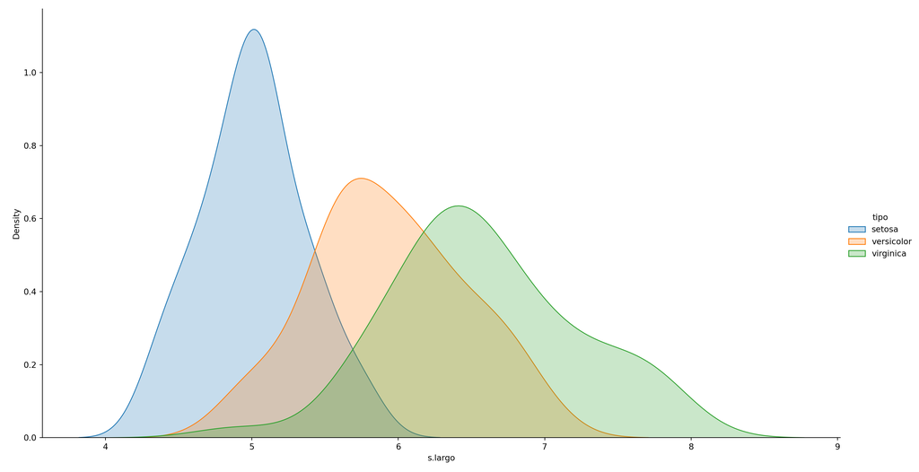

```python
poder_predictivo_numerica(datos,"s.largo","tipo")
plt.show()
```

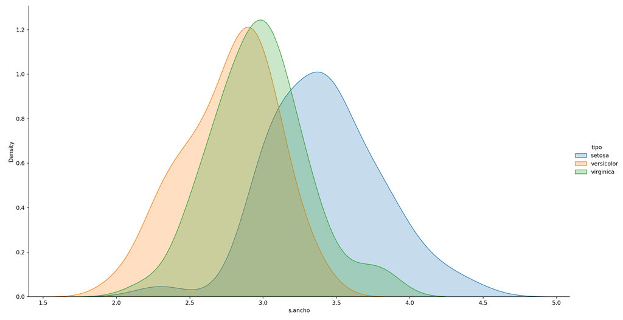

```python
poder_predictivo_numerica(datos,"s.ancho","tipo")
plt.show()
```

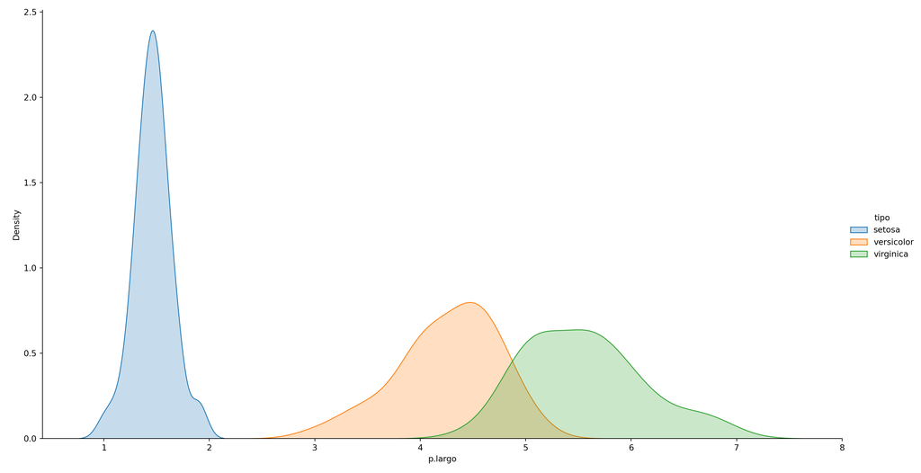

```python
poder_predictivo_numerica(datos,"p.largo","tipo")
plt.show()
```

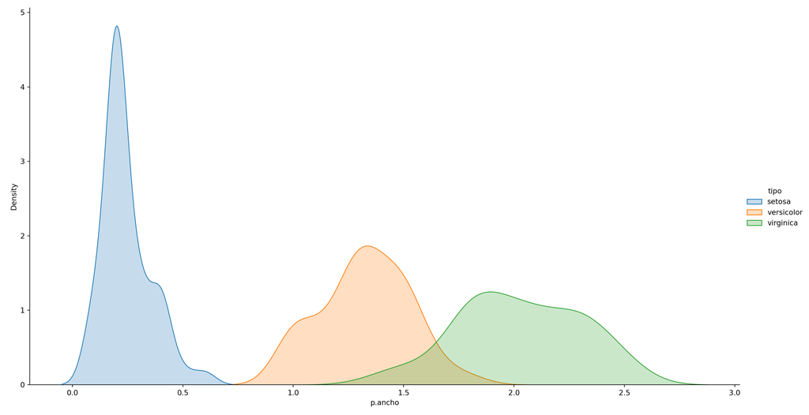

```python
poder_predictivo_numerica(datos,"p.ancho","tipo")
plt.show()
```

**Seleccionamos únicamente las variables predictoras p.largo y p.ancho**

```python
X = datos[["p.largo", "p.ancho"]]
X = pd.DataFrame(StandardScaler().fit_transform(X), columns= X.columns)
print(X.head())
```

```
    p.largo   p.ancho
0 -1.341272 -1.312977
1 -1.341272 -1.312977
2 -1.398138 -1.312977
3 -1.284407 -1.312977
4 -1.341272 -1.312977
```

```python
y = datos.iloc[:,4].ravel()
```

### Genera las tablas de training y testing con el 70% de los datos para entrenamiento

```python
X_train, X_test, y_train, y_test = train_test_split(X, y, train_size=0.7 )
```

### Generamos el modelo, las predicciones y medimos la calidad de las mismas

```python
instancia_knn = KNeighborsClassifier(n_neighbors=5)
instancia_knn.fit(X_train.values,y_train)
```

```
KNeighborsClassifier()
```

```python
prediccion = instancia_knn.predict(X_test.values)

labels = ["setosa","versicolor","virginica"]
MC = confusion_matrix(y_test, prediccion)

indices = indices_general(MC,labels)
for k in indices:
    print("\n%s:\n%s"%(k,str(indices[k])))
```

```
Matriz de Confusión:
[[15  0  0]
 [ 0 14  1]
 [ 0  2 13]]

Precisión Global:
0.9333333333333333

Error Global:
0.06666666666666665

Precisión por categoría:
   setosa  versicolor  virginica
0     1.0    0.933333   0.866667
```

# Ejemplo Scoring de Crédito

**Lectura de datos**

```python
datos = pd.read_csv('../datos/MuestraCredito5000V2.csv', delimiter = ';', decimal = ".", header = 0)
print("Muestra Credito shape", datos.shape, "\n")
```

```
Muestra Credito shape (5000, 6)
```

```python
print("Info:\n",datos.info())
```

```
<class 'pandas.core.frame.DataFrame'>
RangeIndex: 5000 entries, 0 to 4999
Data columns (total 6 columns):
 #   Column             Non-Null Count  Dtype
---  ------             --------------  -----
 0   MontoCredito       5000 non-null   int64
 1   IngresoNeto        5000 non-null   int64
 2   CoefCreditoAvaluo  5000 non-null   int64
 3   MontoCuota         5000 non-null   object
 4   GradoAcademico     5000 non-null   object
 5   BuenPagador        5000 non-null   object
dtypes: int64(3), object(3)
memory usage: 234.5+ KB
Info:
 None
```

```python
datos.head()
```

```
   MontoCredito  IngresoNeto  ...  GradoAcademico BuenPagador
0         14327            1  ...       Bachiller          Si
1        111404            1  ...       Bachiller          Si
2         21128            1  ...       Bachiller          Si
3         15426            2  ...       Bachiller          Si
4         10351            1  ...       Bachiller          Si

[5 rows x 6 columns]
```

### Balance de las clases en la variable a predecir - Problema desvalanceado

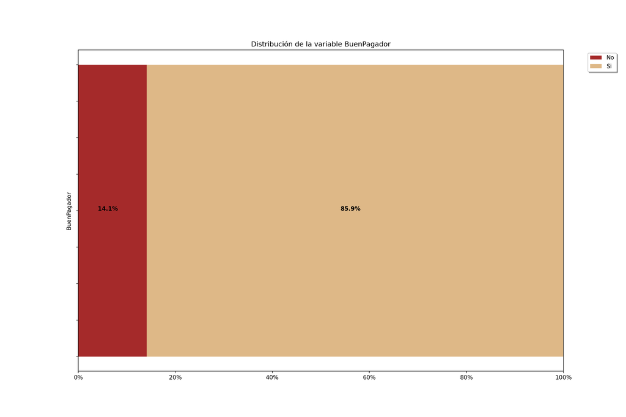

```python
distribucion_variable_predecir(datos,"BuenPagador")
plt.show()
```

**Preparación de datos**

```python
# Convierte las variables a categórica
datos['IngresoNeto'] = datos['IngresoNeto'].astype('category')
datos['MontoCuota'] = datos['MontoCuota'].astype('category')
datos['GradoAcademico'] = datos['GradoAcademico'].astype('category')

# Variable a predecir
y = datos["BuenPagador"].ravel()

#Convertimos a Dummy algunas de las variables predictoras
X = pd.get_dummies(datos.drop(columns=["BuenPagador"]),
                   columns=["IngresoNeto", "MontoCuota", "GradoAcademico"])

#Estandarizamos los datos
X = pd.DataFrame(StandardScaler().fit_transform(X), columns=[X.columns])
X.head()
```

```
  MontoCredito  ... GradoAcademico_Licenciatura
0    -0.585876  ...                   -0.966946
1     1.166762  ...                   -0.966946
2    -0.463090  ...                   -0.966946
3    -0.566035  ...                   -0.966946
4    -0.657659  ...                   -0.966946

[5 rows x 10 columns]
```

### Training-Testing

```python
X_train, X_test, y_train, y_test = train_test_split(X, y, train_size=0.75 )
```

### Genera el modelo, las predicciones y mide la calidad de las mismas

```python
instancia_knn = KNeighborsClassifier(n_neighbors=5)
instancia_knn.fit(X_train.values,y_train)
```

```
KNeighborsClassifier()
```

```python
prediccion = instancia_knn.predict(X_test.values)

labels = ["No","Si"]
MC = confusion_matrix(y_test, prediccion, labels=labels)

indices = indices_general(MC,labels)
for k in indices:
    print("\n%s:\n%s"%(k,str(indices[k])))
```

```
Matriz de Confusión:
[[ 115   61]
 [  18 1056]]

Precisión Global:
0.9368

Error Global:
0.06320000000000003

Precisión por categoría:
         No       Si
0  0.653409  0.98324
```

# Ejemplo con SAHeart

**Lectura de datos**

```python
datos = pd.read_csv('../datos/SAheart.csv', delimiter = ';', decimal = ".")
print("SAheart shape: ", datos.shape, "\n")
```

```
SAheart shape:  (462, 10)
```

```python
print(datos.info(), "\n")
```

```
<class 'pandas.core.frame.DataFrame'>
RangeIndex: 462 entries, 0 to 461
Data columns (total 10 columns):
 #   Column     Non-Null Count  Dtype
---  ------     --------------  -----
 0   sbp        462 non-null    int64
 1   tobacco    462 non-null    float64
 2   ldl        462 non-null    float64
 3   adiposity  462 non-null    float64
 4   famhist    462 non-null    object
 5   typea      462 non-null    int64
 6   obesity    462 non-null    float64
 7   alcohol    462 non-null    float64
 8   age        462 non-null    int64
 9   chd        462 non-null    object
dtypes: float64(5), int64(3), object(2)
memory usage: 36.2+ KB
None
```

```python
datos.head()
```

```
   sbp  tobacco   ldl  adiposity  famhist  typea  obesity  alcohol  age chd
0  160    12.00  5.73      23.11  Present     49    25.30    97.20   52  Si
1  144     0.01  4.41      28.61   Absent     55    28.87     2.06   63  Si
2  118     0.08  3.48      32.28  Present     52    29.14     3.81   46  No
3  170     7.50  6.41      38.03  Present     51    31.99    24.26   58  Si
4  134    13.60  3.50      27.78  Present     60    25.99    57.34   49  Si
```

### Equilibrio de la variable a predecir

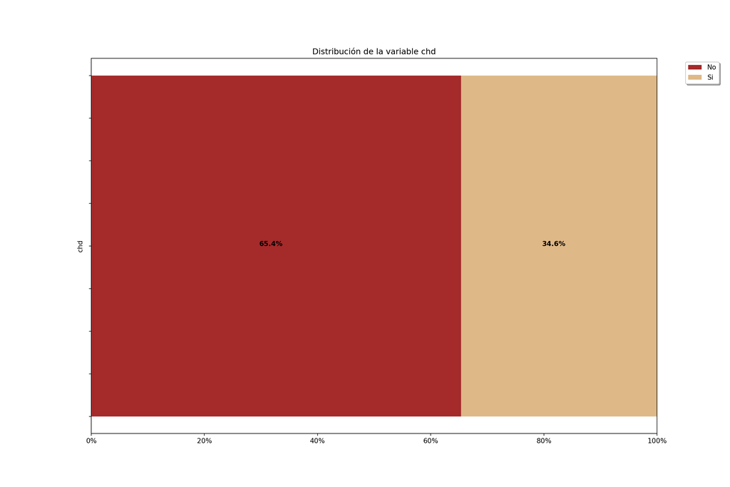

```python
distribucion_variable_predecir(datos,"chd")
plt.show()
```

**Preparación de Datos**

```python
# Convierte las variables de object a categórica
datos['famhist'] = datos['famhist'].astype('category')

# Variable a predecir
y = datos["chd"].ravel()

#Convertimos a Dummy algunas de las variables predictoras
X = pd.get_dummies(datos.drop(columns=["chd"]),
                   columns=["famhist"])

#Estandarizamos los datos
X = pd.DataFrame(StandardScaler().fit_transform(X), columns=[X.columns])
X.head()
```

```
        sbp   tobacco       ldl  ...       age famhist_Absent famhist_Present
0  1.058564  1.823073  0.478412  ...  0.629336      -1.185854        1.185854
1  0.277089 -0.790237 -0.159680  ...  1.383115       0.843274       -0.843274
2 -0.992806 -0.774980 -0.609245  ...  0.218184      -1.185854        1.185854
3  1.546985  0.842264  0.807126  ...  1.040488      -1.185854        1.185854
4 -0.211332  2.171805 -0.599577  ...  0.423760      -1.185854        1.185854

[5 rows x 10 columns]
```

## Training-Testing

```python
X_train, X_test, y_train, y_test = train_test_split(X, y, train_size=0.80 )
```

### Genera el modelo, las predicciones y mide la calidad

```python
instancia_knn = KNeighborsClassifier(n_neighbors=17)
instancia_knn.fit(X_train.values,y_train)
```

```
KNeighborsClassifier(n_neighbors=17)
```

```python
prediccion = instancia_knn.predict(X_test.values)

labels = ["No","Si"]
MC = confusion_matrix(y_test, prediccion)

indices = indices_general(MC,labels)
for k in indices:
    print("\n%s:\n%s"%(k,str(indices[k])))
```

```
Matriz de Confusión:
[[51  9]
 [24  9]]

Precisión Global:
0.6451612903225806

Error Global:
0.3548387096774194

Precisión por categoría:
     No        Si
0  0.85  0.272727
```

## Selección de variables

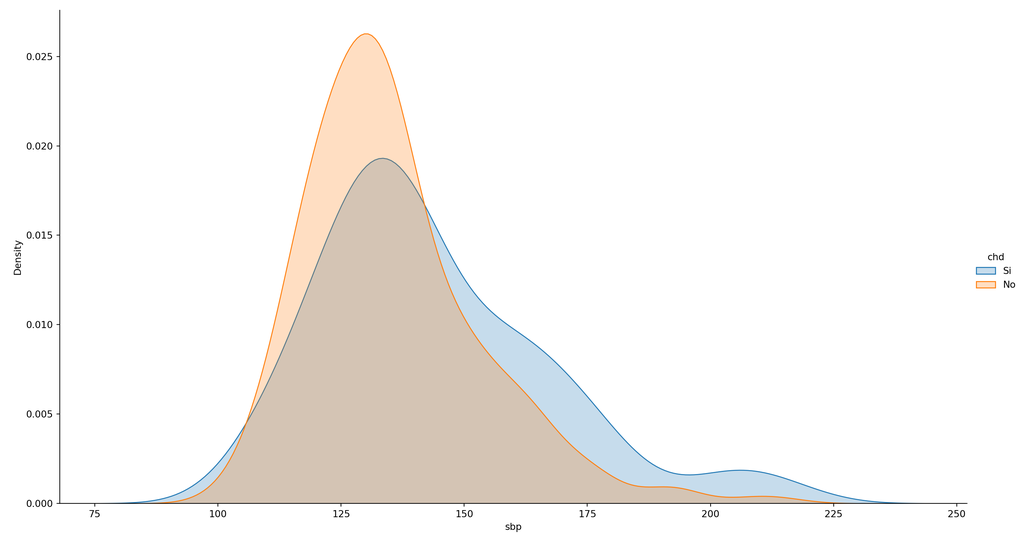

```python
poder_predictivo_numerica(datos,"sbp","chd")
plt.show()
```

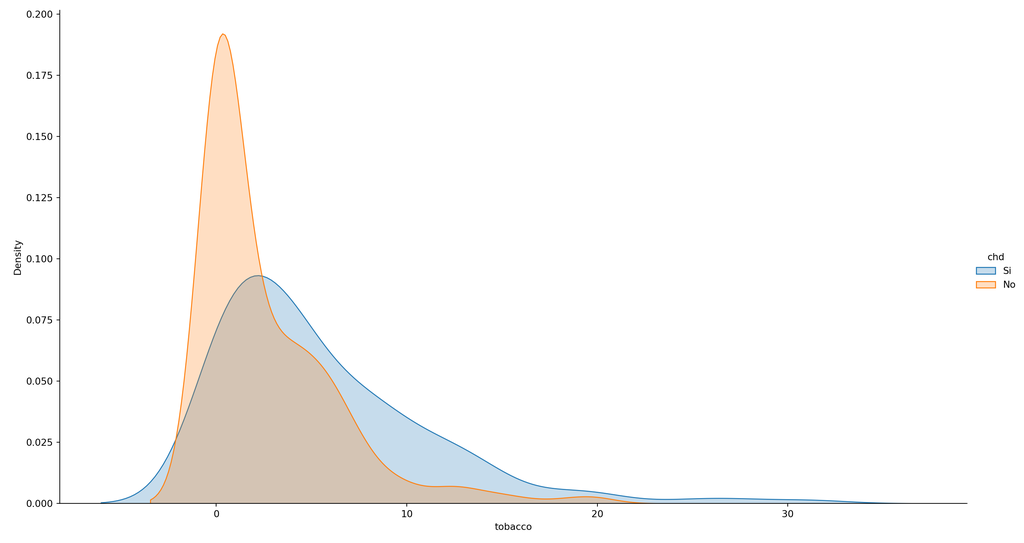

```python
poder_predictivo_numerica(datos,"tobacco","chd")
plt.show()
```

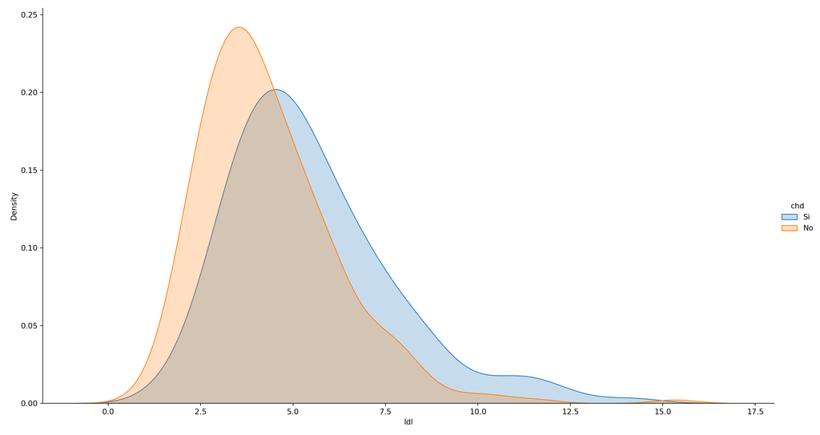

```python
poder_predictivo_numerica(datos,"ldl","chd")
plt.show()
```

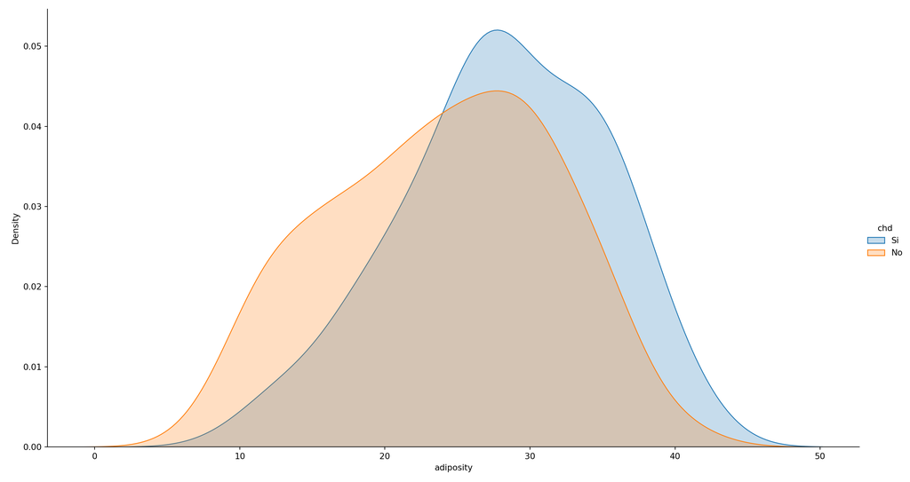

```python
poder_predictivo_numerica(datos,"adiposity","chd")
plt.show()
```

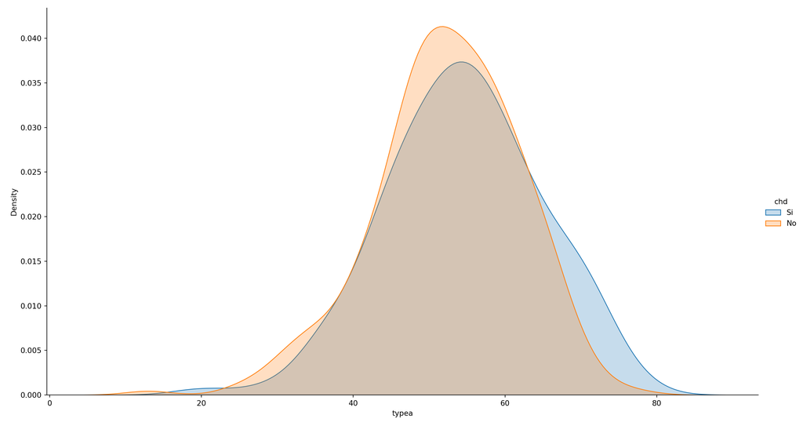

```python
poder_predictivo_numerica(datos,"typea","chd")
plt.show()
```

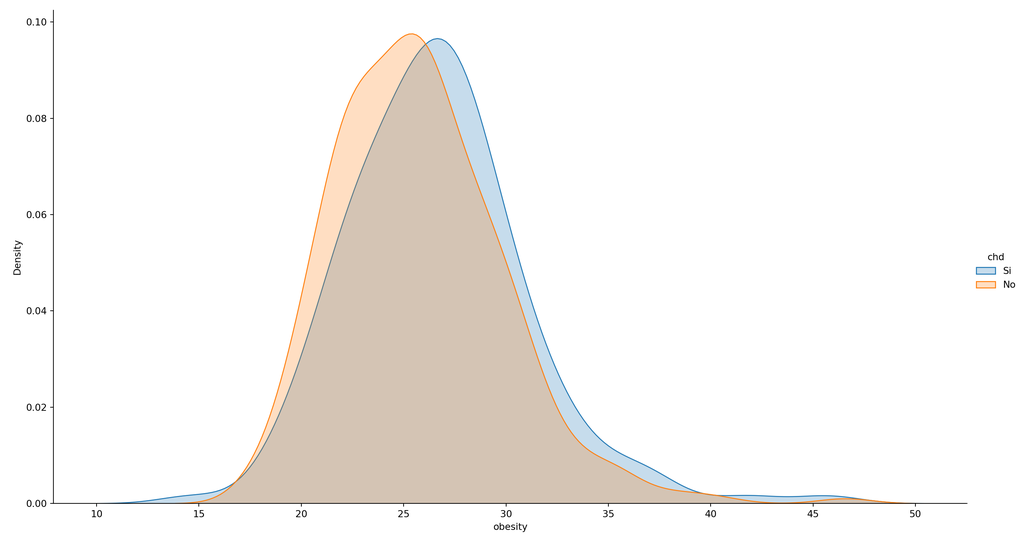

```python
poder_predictivo_numerica(datos,"obesity","chd")
plt.show()
```

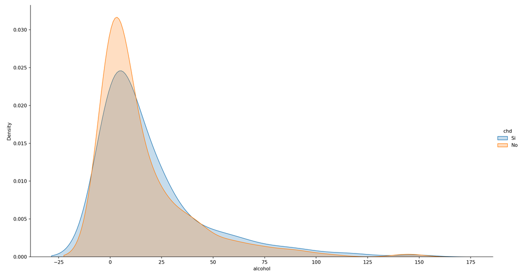

```python
poder_predictivo_numerica(datos,"alcohol","chd")
plt.show()
```

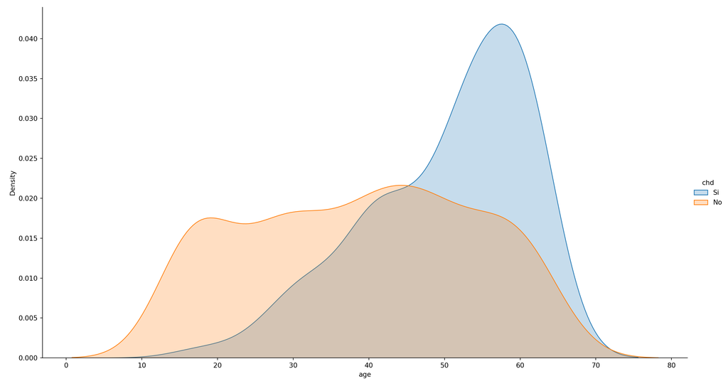

```python
poder_predictivo_numerica(datos,"age","chd")
plt.show()
```

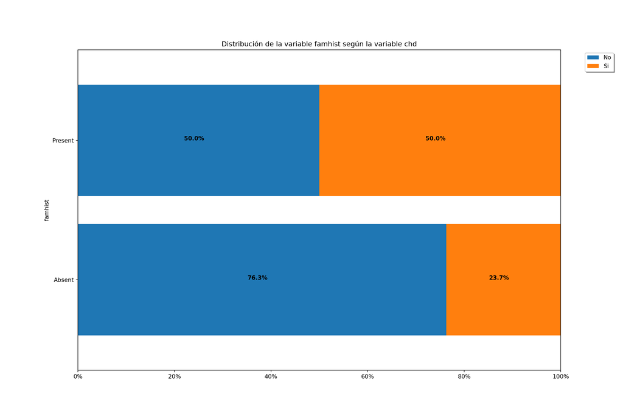

```python
poder_predictivo_categorica(datos,"famhist","chd")
plt.show()
```

### Selección de variables

```python
X = X[["ldl", "age", "tobacco", "famhist_Absent", "famhist_Present"]]
X.head()
```

```
        ldl       age   tobacco famhist_Absent famhist_Present
0  0.478412  0.629336  1.823073      -1.185854        1.185854
1 -0.159680  1.383115 -0.790237       0.843274       -0.843274
2 -0.609245  0.218184 -0.774980      -1.185854        1.185854
3  0.807126  1.040488  0.842264      -1.185854        1.185854
4 -0.599577  0.423760  2.171805      -1.185854        1.185854
```

### Training-Testing

```python
X_train, X_test, y_train, y_test = train_test_split(X, y, train_size=0.80 )
```

### Genera el modelo predictivo, las predicciones y mide la calidad

```python
instancia_knn = KNeighborsClassifier(n_neighbors=17)
instancia_knn.fit(X_train.values,y_train)
```

```
KNeighborsClassifier(n_neighbors=17)
```

```python
prediccion = instancia_knn.predict(X_test.values)

labels = ["No","Si"]
MC = confusion_matrix(y_test, prediccion,labels=labels)

indices = indices_general(MC,labels)
for k in indices:
    print("\n%s:\n%s"%(k,str(indices[k])))
```

```
Matriz de Confusión:
[[54  6]
 [15 18]]

Precisión Global:
0.7741935483870968

Error Global:
0.22580645161290325

Precisión por categoría:
    No        Si
0  0.9  0.545455
```